# Отчёт по лабораторной работе №4

Первоначальное конфигурирование сети

Илья Колонтырский

Российский университет дружбы народов, Москва, Россия

# Цели и задачи работы

## Цель лабораторной работы

Выполнить подготовительную работу по первоначальной настройке коммутаторов сети в Cisco Packet Tracer: - собрать физическую топологию (L1), - назначить имена устройств и IP-адреса управления, - настроить базовые параметры доступа и безопасности, - подготовить доступ к управлению (VTY/SSH).

## Задачи

- Разместить коммутаторы и конечные устройства согласно схеме L1.
- Соединить устройства через соответствующие интерфейсы.
- Настроить на коммутаторах интерфейс управления VLAN 2.
- Задать шлюз по умолчанию для управления.
- Настроить VTY/Console, enable secret, шифрование паролей, локального пользователя.
- Подготовить SSH (domain-name, RSA-ключи, transport input ssh).
- Сохранить конфигурацию.

# Физическая топология сети (L1)

## Размещение устройств и соединения

В Packet Tracer размещены и подключены: - коммутаторы: msk-donskaya-irkolontirskiy-sw-1, sw-2, sw-3, sw-4, msk-pavlovskaya-irkolontirskiy-sw-1 - ПК: dk-pavlovskaya-irkolontirskiy-1, other-pavlovskaya-irkolontirskiy-1, dk-donskaya-irkolontirskiy-1, dep-donskaya-irkolontirskiy-1, adm-donskaya-irkolontirskiy-1, other-donskaya-irkolontirskiy-1 - серверы: web-irkolontirskiy, file-irkolontirskiy, mail-irkolontirskiy

Межкоммутаторные соединения выполнены магистральными линиями, конечные устройства подключены к access-портам.

## Схема L1

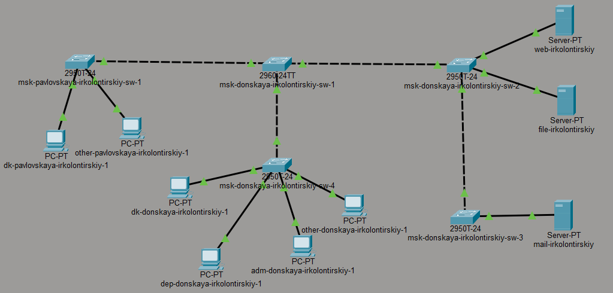

Схема L1

# Адресация управления (VLAN 2)

## Таблица IP-адресов управления

| Устройство | Интерфейс | IP-адрес | Маска | Шлюз |
| --- | --- | --- | --- | --- |
| msk-donskaya-irkolontirskiy-sw-1 | Vlan2 | 10.128.1.2 | 255.255.255.0 | 10.128.1.1 |
| msk-donskaya-irkolontirskiy-sw-2 | Vlan2 | 10.128.1.3 | 255.255.255.0 | 10.128.1.1 |
| msk-donskaya-irkolontirskiy-sw-3 | Vlan2 | 10.128.1.4 | 255.255.255.0 | 10.128.1.1 |
| msk-donskaya-irkolontirskiy-sw-4 | Vlan2 | 10.128.1.5 | 255.255.255.0 | 10.128.1.1 |
| msk-pavlovskaya-irkolontirskiy-sw-1 | Vlan2 | 10.128.1.6 | 255.255.255.0 | 10.128.1.1 |

# Подтверждение настроек (CLI)

## msk-donskaya-irkolontirskiy-sw-1

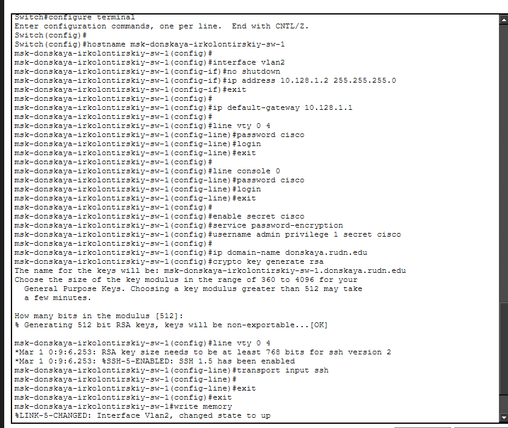

CLI sw-1

## msk-donskaya-irkolontirskiy-sw-2

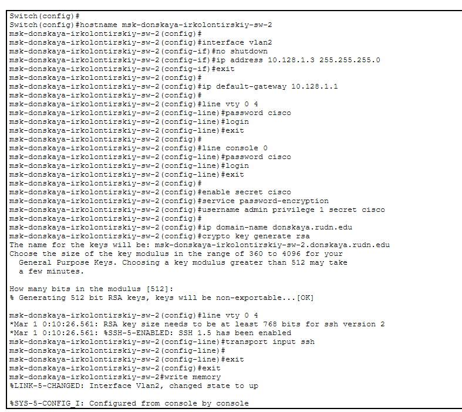

CLI sw-2

## msk-donskaya-irkolontirskiy-sw-3

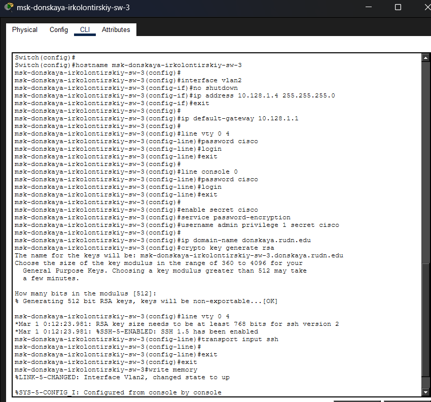

CLI sw-3

## msk-donskaya-irkolontirskiy-sw-4

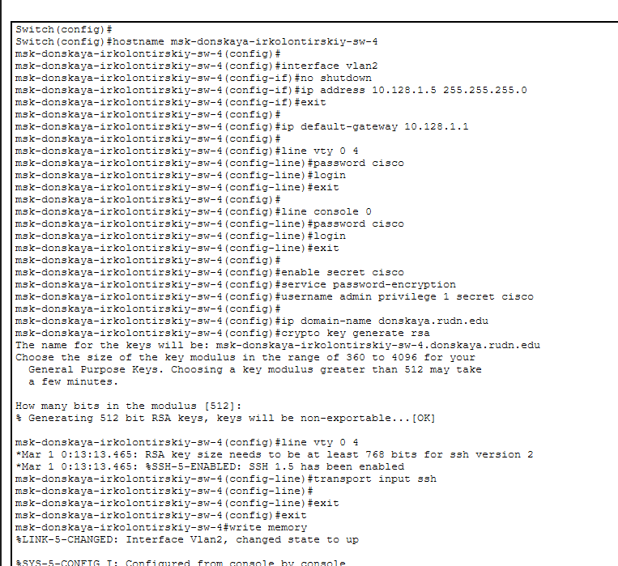

CLI sw-4

## msk-pavlovskaya-irkolontirskiy-sw-1

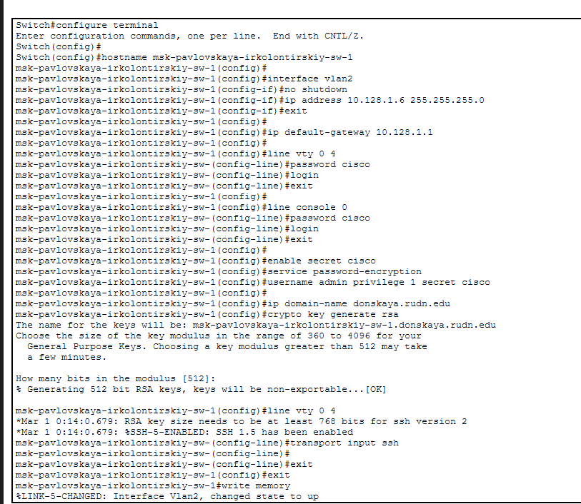

CLI pavlovskaya-sw-1

# Выводы

## Вывод

В Cisco Packet Tracer собрана физическая топология сети (L1) и выполнена базовая настройка всех коммутаторов.

На уровне управления настроен интерфейс VLAN 2 для каждого коммутатора, назначены IP-адреса из 10.128.1.0/24 и задан единый шлюз 10.128.1.1, что обеспечивает централизованный доступ к управлению.